Jonathan Dorsey, Derrin Ngo, Chandler Yoon, Min Ho Lee

# NBA Position Predictions

## Background

The National Basketball Association (NBA) is the premier basketball league for North America. It is widely regarded as the most competitive league in the world. Play consists of two teams, each with five players on the court at all times. Traditionally, a five-man lineup would consist of five unique positions: a point guard (PG), a shooting guard (SG), a small forward (SF), a power forward (PF), and a center (C). Each of these positions performs a unique role on the team, albiet with some overlap between positions. For example, a point guard traditionally runs the team's offense (handles the ball, calls plays to run, excels in passing the ball, etc).

### Problem

Can one predict the position a NBA player plays based on their box-score statistics? Or in other words, does a player's performace indicate the position they play?

### Significance

This is an incredibly important scouting problem for NBA teams. Often, the transition from amateur basketball, college basketball, or other professional leagues is wrought with missclassification or missidentification of talent. NBA scouts will try to fill gaps in their roster by acquiring players from college teams (through the NBA draft) or signing amateur/professional players from other basketball leagues. However, as stated above, the level of competition in the NBA is unparalleled, and as such the role a college or semi-pro player plays on their original team will likely not be the same role they play in the NBA. Creating a classification system which identifies the position a player plays based on their statistics would mitigate the risks associated with acquiring players from leagues outside of the NBA. Likewise, once a player arrives in the NBA, a predictive model could help identify if coaches are playing a player at the wrong position based on the performance of that player.

```python
import pandas as pd
```

```python
data = pd.read_csv('nba_stats.csv')
print(data.shape)
```

```
(24630, 54)
```

## Dataset

Our [dataset](https://github.com/peasant98/TheNBACSV) contains box-score statistics on every NBA player for every NBA season from 1950 to 2017. There are 24,630 records, each with 54 attributes. These attributes include basic counting stats such as points, rebounds, assists, steals, and blocks, as well as advanced statistics such as true-shooting percentage. All of the 54 attributes are described in the notebook glossary. Each record in the dataset is a single player's statistics for a single season.

```python
print(data.head())
```

```
        #  SeasonStart  PlayerName   PlayerSalary  Pos   Age   Tm     G    GS  \
0  8035.0       1986.0  A.C. Green             NaN  PF  22.0  LAL  82.0   1.0
1  8420.0       1987.0  A.C. Green             NaN  PF  23.0  LAL  79.0  72.0
2  8807.0       1988.0  A.C. Green             NaN  PF  24.0  LAL  82.0  64.0
3  9242.0       1989.0  A.C. Green             NaN  PF  25.0  LAL  82.0  82.0
4  9688.0       1990.0  A.C. Green  $1,750,000.00   PF  26.0  LAL  82.0  82.0

       MP   ...       FT%    ORB    DRB    TRB    AST   STL   BLK    TOV  \
0  1542.0   ...    61.10%  160.0  221.0  381.0   54.0  49.0  49.0   99.0
1  2240.0   ...    78.00%  210.0  405.0  615.0   84.0  70.0  80.0  102.0
2  2636.0   ...    77.30%  245.0  465.0  710.0   93.0  87.0  45.0  120.0
3  2510.0   ...    78.60%  258.0  481.0  739.0  103.0  94.0  55.0  119.0
4  2709.0   ...    75.10%  262.0  450.0  712.0   90.0  66.0  50.0  116.0

      PF     PTS
0  229.0   521.0
1  171.0   852.0
2  204.0   937.0
3  172.0  1088.0
4  207.0  1061.0

[5 rows x 54 columns]
```

## Data Exploration

As stated above, there are five traditional positions in NBA basketball: the point guard, shooting guard, small forward, power forward, and center. However, occasionally players will be listed at a combination of positions, like PG-SG.

```python
data.Pos.value_counts()
```

```
PF       4966
SG       4811
C        4759
SF       4699
PG       4648
G         139
F         123
F-C        81
G-F        79
F-G        60
C-F        35
C-PF       33
SF-SG      30
PG-SG      28
SG-PG      27
PF-C       27
SG-SF      26
PF-SF      25
SF-PF      21
SG-PF       3
C-SF        2
PG-SF       1
SF-PG       1
Name: Pos, dtype: int64
```

For our purpose, we will only consider the five traditional roles as having a player listed at a combination of positions is quite rare. Usually, players will only be listed at two positions if they transition midway through the season to the other position. Only 3% of all our records are listed at position combinations.

```python
positions = ['PG', 'SG', 'SF', 'PF', 'C']
data = data[data['Pos'].isin(positions)]
```

We could expect each of the traditional positions to have a general trend in their box-score statistics.

- **Point Guard**: The player to normally bring the ball down and start each play. We could see increased numbers in assists and usage since they will be the main ball handler. Also, the number of steals they have could be higher compared to the other positions because they are the quickest.
- **Shooting Guard**: Shooting guards and small forwards are usually referred to as "wings" because of their positioning: they tend to hover further away the basket, typically around the 3 point line. One of the main objectives for the shooting guard is to score points for their team, so they typically will have a higher total points statline. They also act as secondary ball handlers.
- **Small Forward**: Small forwards tend to be the most versatile players on the court. They tend to have a well-rounded offensive skillset and can defend well because of their length. Therefore, we would expect a more even statline because small forwards have the skills to perform many roles.
- **Power Forward**: As these players tend to stay closer to the rim than the other positions (besides the center), we could expect to see increased blocks, rebounds, and 2 point field goal percentage since they tend to be bigger and play closer to rim.
- **Center**: The player who is normally the biggest and tallest on the court, so we could expect see large increases in blocks and rebounds and a small increase in FG% (shooting closest to rim).

The graphs below show some of the stats from our dataset from each position. Using this graph, we can see some of the general trends for each position explained above.

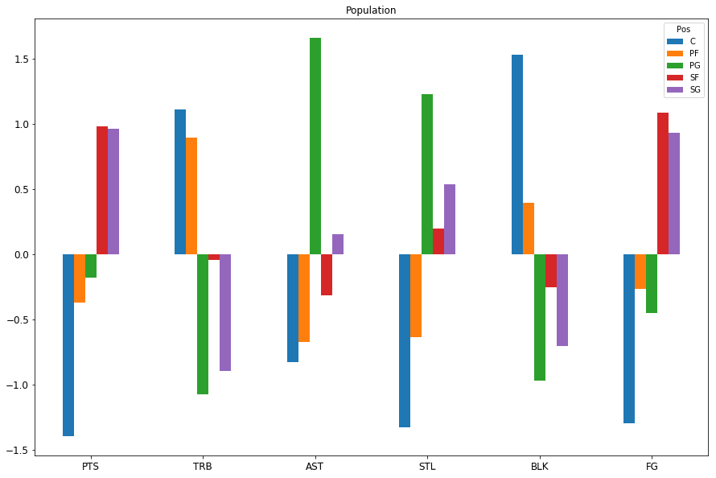

```python
from matplotlib import pyplot as plt

grouped = data.groupby('Pos')
index = ['PTS', 'TRB', 'AST', 'STL', 'BLK', 'FG']
vals = grouped.mean().round(2).loc[:, index]
norm = ((vals - vals.mean())/(vals.std()))
norm = norm.swapaxes("index", "columns")
norm.plot.bar(rot=1, title='Population', figsize=(15,10), fontsize=12)
plt.show()
```

The graphs below show the 3-point shot selection disparity among the different positions.

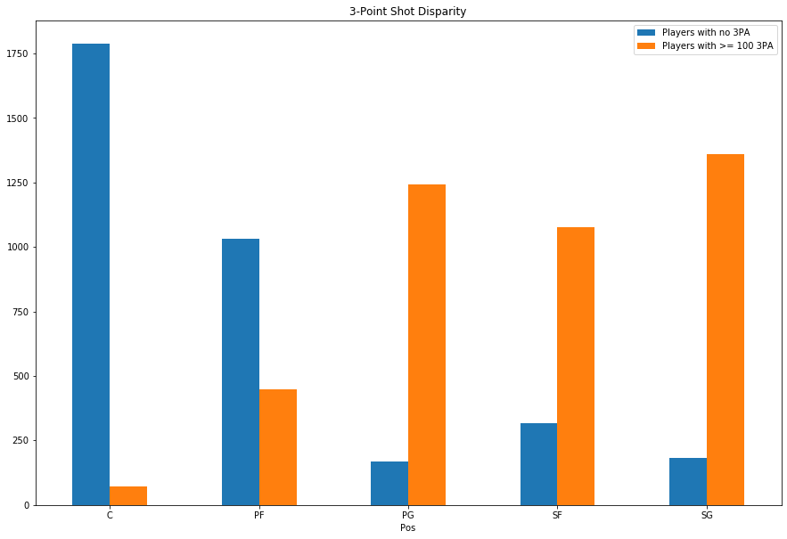

```python
temp = data[data['3PA'] == 0]
temp2 = data[data['3PA'] >= 100]
vals = temp.groupby('Pos').size()
vals2 = temp2.groupby('Pos').size()

fig, ax = plt.subplots(figsize=(15,10))

pd.concat([vals, vals2], axis=1).plot.bar(rot=1, title='3-Point Shot Disparity', ax=ax)
ax.legend(["Players with no 3PA", "Players with >= 100 3PA"]);
plt.show()
```

## Data Cleaning

The **#** attribute in our dataset was a unique identifier for each player's season. Instead of using this unique identifier, we will use index assigned by pandas. As the **blank2** and **blanl** were placeholders for the original aggregator of the dataset, we will also drop them from our dataframe.

```python
data = data.drop(['#', 'blanl', 'blank2'], axis=1)
```

We also only want to consider seasons after the introduction of the 3-point shot into the NBA. The 3-point shot was introduced in the 1979-1980 NBA season which is considered the start of the "[modern era](https://www.usab.com/youth/news/2011/06/the-history-of-the-3-pointer.aspx)" of basketball. After the introduction of the 3-point shot, the frontcourt (SF, PF, and C) and backcourt (PG, SG) started to define their roles more distinctly, with guards and small forwards tending to have better 3-point shooting capabilities than the other positions.

```python
data = data[data['SeasonStart'] >= 1980]
```

We also see that some of the data was interpreted in a non-numerical way, so we cast them to be numerical values to scale and also graph.

```python
print(data.dtypes)
data['TS%'] = pd.to_numeric(data['TS%'].str.strip('%'))
data['FG%'] = pd.to_numeric(data['FG%'].str.strip('%'))
data['FTr'] = pd.to_numeric(data['FTr'].str.strip('%'))
data['2P%'] = pd.to_numeric(data['2P%'].str.strip('%'))
data['eFG%'] = pd.to_numeric(data['eFG%'].str.strip('%'))
data['FT%'] = pd.to_numeric(data['FT%'].str.strip('%'))
```

```
SeasonStart      float64
PlayerName        object
PlayerSalary      object
Pos               object
Age              float64
Tm                object
G                float64
GS               float64
MP               float64
PER              float64
TS%               object
3PAr             float64
FTr               object
ORB%             float64
DRB%             float64
TRB%             float64
AST%             float64
STL%             float64
BLK%             float64
TOV%             float64
USG%             float64
OWS              float64
DWS              float64
WS               float64
WS/48            float64
OBPM             float64
DBPM             float64
BPM              float64
VORP             float64
FG               float64
FGA              float64
FG%               object
3P               float64
3PA              float64
3P%              float64
2P               float64
2PA              float64
2P%               object
eFG%              object
FT               float64
FTA              float64
FT%               object
ORB              float64
DRB              float64
TRB              float64
AST              float64
STL              float64
BLK              float64
TOV              float64
PF               float64
PTS              float64
dtype: object
```

Finally, we only want to consider players that played at least 311 minutes in a particular season. 311 minutes per season is the 25% of minutes played throughout NBA history per season. Each NBA season consists of 82 games of 48 minutes, or 3,936 minutes of gametime for a player to play in. Players with less than 311 minutes of gametime simply do not record enough statistics to be significant because they will be playing fewer than 7 minutes per game.

```python
minutes = data['MP']
cutoff = int(minutes.quantile(.25))
print('The 25th percentile of our dataset is:', cutoff, 'minutes.')
data = data[data['MP'] >= cutoff]
print('\nNumber of NaN values for each attribute:')
print(data.isna().sum())
```

```
The 25th percentile of our dataset is: 311 minutes.

Number of NaN values for each attribute:
SeasonStart         0
PlayerName          0
PlayerSalary     5016
Pos                 0
Age                 0
Tm                  0
G                   0
GS                556
MP                  0
PER                 0
TS%                 0
3PAr                0
FTr                 0
ORB%                0
DRB%                0
TRB%                0
AST%                0
STL%                0
BLK%                0
TOV%                0
USG%                0
OWS                 0
DWS                 0
WS                  0
WS/48               0
OBPM                0
DBPM                0
BPM                 0
VORP                0
FG                  0
FGA                 0
FG%                 0
3P                  0
3PA                 0
3P%              1495
2P                  0
2PA                 0
2P%                 0
eFG%                0
FT                  0
FTA                 0
FT%                 3
ORB                 0
DRB                 0
TRB                 0
AST                 0
STL                 0
BLK                 0
TOV                 0
PF                  0
PTS                 0
dtype: int64
```

**Note**: for our analyis, we did not use any of the attributes with NaN values. Our methodology for attribute selection is described below.

## Feature Engineering

There are a variety of "positionless" statistics that players record regardless of the position they play. In our case, these include:

- **WS, WS/48, OWS, DWS**: Win Shares; metrics designed to estimate the number of wins a player contributes to their team's total wins
- **G, GS**: Games and games started; number of games a player played in that season and the number of games a player started that season, respectively
- **PF**: Personal Fouls; the number of fouls commited by a player during the season
- **PER**: Player Efficiency Rating; a rating indicating a player's per-minute performance while on the court
- **MP**: Minutes Played; number of minutes a player plays that season)
- **BPM, OBPM, and DBPM**: Box plus-minus; box score-based metric that estimates a basketball player’s offensive contribution to the team when that player is on the court
- **VORP**: Value over Replacement Player; an estimate of each player's contribution to their team relative to a "replacement-level" player

```python
games_played = data['G']
data = data.drop(['WS', 'WS/48', 'OWS', 'DWS', 'G', 'GS', 'PER', 'MP', 'BPM', 'OBPM', 'DBPM', 'VORP', 'PF'], axis=1)
print(data.columns)
```

```
Index(['SeasonStart', 'PlayerName', 'PlayerSalary ', 'Pos', 'Age', 'Tm', 'TS%',
       '3PAr', 'FTr', 'ORB%', 'DRB%', 'TRB%', 'AST%', 'STL%', 'BLK%', 'TOV%',
       'USG%', 'FG', 'FGA', 'FG%', '3P', '3PA', '3P%', '2P', '2PA', '2P%',
       'eFG%', 'FT', 'FTA', 'FT%', 'ORB', 'DRB', 'TRB', 'AST', 'STL', 'BLK',
       'TOV', 'PTS'],
      dtype='object')
```

In addition, there are a few attributes in our dataset that are entirely irrelevant for our exploration. These attributes (especially PlayerSalary) would make good labels for another classification problem.

- **SeasonStart**: the year the season described by that record began
- **PlayerName**: the name of the player whose stats for that season are contained by that record
- **PlayerSalary**: the amount of money being paid to that player for that season
- **Age**: the age of the player during that season
- **Tm**: the team that player played on during that season

```python
data = data.drop(['SeasonStart', 'PlayerName', 'PlayerSalary ', 'Age', 'Tm'], axis=1)
print(data.columns)
```

```
Index(['Pos', 'TS%', '3PAr', 'FTr', 'ORB%', 'DRB%', 'TRB%', 'AST%', 'STL%',
       'BLK%', 'TOV%', 'USG%', 'FG', 'FGA', 'FG%', '3P', '3PA', '3P%', '2P',
       '2PA', '2P%', 'eFG%', 'FT', 'FTA', 'FT%', 'ORB', 'DRB', 'TRB', 'AST',
       'STL', 'BLK', 'TOV', 'PTS'],
      dtype='object')
```

Finally, there are some attributes that are derived from others in the dataset. To decrease redundancy and dimensionality, we eliminated these from our dataset.

- **3P%** = 3P / 3PA
- **2P%** = 2P / 2PA
- **FG%** = FG / FGA
- **FT%** = FT / FTA
- **FTr** = FTA / FGA
- **eFG%** = (FG + .5 * 3P) / FGA
- **FG** = 2P + 3P
- **TRB** = ORB + DRB
- **PTS** = 3 *3P + 2* 2P + FT
- **FGA** = 3PA + 2PA
- **3PAr** = 3PA / FGA
- **TS%** = PTS / ( 2 *(FGA + 0.44* FTA))

```python
data = data.drop(['3P%', '2P%', 'FG%', 'FT%', 'FTr', 'eFG%', 'FG', 'TRB', 'PTS', 'FGA', '3PAr', 'TS%'], axis=1)
print(data.columns)
```

```
Index(['Pos', 'ORB%', 'DRB%', 'TRB%', 'AST%', 'STL%', 'BLK%', 'TOV%', 'USG%',
       '3P', '3PA', '2P', '2PA', 'FT', 'FTA', 'ORB', 'DRB', 'AST', 'STL',
       'BLK', 'TOV'],
      dtype='object')
```

One possible issue with the current data is stat inflation. Players stats scale with the amount of playing time they get (MP). To resolve this issue, we decided to scale some of the data on a per-minute basis. Because the percentages are already scaled, we will be scaling **3P, 3PA, 2P, 2PA FT, FTA, ORB, DRB, AST, STL, BLK, TOV** by dividing all of those numbers by the number of minutes that that player has played.

```python
counting_stats = ['3P', '3PA', '2P', '2PA', 'FT', 'FTA', 'ORB', 'DRB', 'AST', 'STL', 'BLK', 'TOV']
data[counting_stats] = data[counting_stats].div(minutes, axis=0)
print(data[counting_stats].head())
```

```
         3P       3PA        2P       2PA        FT       FTA       ORB  \
0  0.000649  0.003891  0.134890  0.247730  0.066148  0.108301  0.103761
1  0.000000  0.002232  0.141071  0.259821  0.098214  0.125893  0.093750
2  0.000000  0.000759  0.122155  0.242033  0.111153  0.143778  0.092944
3  0.001594  0.006773  0.158167  0.295219  0.112351  0.143028  0.102789
4  0.004799  0.016980  0.137320  0.280546  0.102621  0.136582  0.096715

        DRB       AST       STL       BLK       TOV
0  0.143320  0.035019  0.031777  0.031777  0.064202
1  0.180804  0.037500  0.031250  0.035714  0.045536
2  0.176404  0.035281  0.033005  0.017071  0.045524
3  0.191633  0.041036  0.037450  0.021912  0.047410
4  0.166113  0.033223  0.024363  0.018457  0.042820
```

Our final data set contains 14,057 records with 20 attributes and 1 class label.

```python
print(data.shape)
```

```
(14057, 21)
```

## Data Analysis

```python
import sklearn as sk
from sklearn.model_selection import cross_val_score, cross_val_predict, GridSearchCV
from sklearn.tree import DecisionTreeClassifier
from sklearn.svm import SVC
from sklearn.preprocessing import StandardScaler
from sklearn.decomposition import PCA
from sklearn.neighbors import KNeighborsClassifier
from sklearn.naive_bayes import GaussianNB
from sklearn.pipeline import Pipeline
from sklearn.neural_network import MLPClassifier
from sklearn.ensemble import RandomForestClassifier, VotingClassifier
from sklearn.metrics import classification_report, confusion_matrix
```

```python
from warnings import filterwarnings
filterwarnings('ignore')
```

First, we split the data into **features** and **labels**.

```python
# FOR TESTING, UNCOMMENT FOLLOWING LINE
# data = data.sample(500)
features = data.drop('Pos', axis=1)
labels = data['Pos']
```

We decided to begin our analysis using a decision tree. Decision trees excel at dealing with noise, which would help deal with the skill gap of star players' stats when compared to average NBA players. Decision trees also partition the dataset along axis-parallel hyperplanes, which will help to classify players of the same position as they tend to record similar stats.

```python
def decision_tree(features, labels):
    clf = DecisionTreeClassifier()
    params = {'max_depth': [5, 10, 15, 20],
              'min_samples_leaf': [5, 10, 15, 20],
              'max_features': list(range(5, 21))}

    grid_search = GridSearchCV(clf, params, cv=5, scoring='accuracy')
    grid_search.fit(features, labels)

    print('Best params:', grid_search.best_params_)
    print('Accuracy:', grid_search.best_score_ * 100)

    return grid_search

# for use in our voting ensemble
clf0 = decision_tree(features, labels)
```

```
Best params: {'max_depth': 5, 'max_features': 17, 'min_samples_leaf': 20}
Accuracy: 63.35633492210286
```

Next, we decided to continue our analysis by using the K-Nearest Neighbors algorithm. Of course, KNN needs data to be scaled (in order to prevent attribute domination) so we used a pipeline with a scaler. Similarly, KNN is susceptible to the curse of dimensionality, and our dataset has 20 attributes. As such, we decided to use principle component analysis in our pipeline to determine the ideal number of attributes to use in our classification.

```python
def knn(features, labels):
    scaler = StandardScaler()
    pca = PCA()
    KNN = KNeighborsClassifier()
    pipeline = Pipeline([('scaler', scaler), ('PCA', pca), ('KNN', KNN)])
    param_grid = {
        'PCA__n_components': list(range(5, 21)),
        'KNN__n_neighbors': list(range(1, 15))
    }

    grid_search = GridSearchCV(pipeline, param_grid, cv=5, scoring='accuracy')
    grid_search.fit(features, labels)

    print('Best params:', grid_search.best_params_)
    print('Accuracy:', grid_search.best_score_ * 100)

    return grid_search

# for use in our voting ensemble
clf1 = knn(features, labels)
```

```
Best params: {'KNN__n_neighbors': 13, 'PCA__n_components': 11}
Accuracy: 63.150032012520455
```

Next up is Naive Bayes. Contrary to KNN, Bayesian classification does not suffer from the curse of dimensionality, meaning we will not have to use PCA to select features for classification. However, Naive Bayes assumes that all features are independent of one another. With basketball, we know this is not the case (players with more assists will take fewer shots and have more turnovers, players with more 2-pointers will take fewer 3-pointers, etc.).

```python
def naive_bayes(features, labels):
    nb = GaussianNB()

    scores = cross_val_score(nb, features, labels, cv=10)
    print('Accuracy:', scores.mean() * 100)

    return nb

# for use in our voting ensemble
clf2 = naive_bayes(features, labels)
```

```
Accuracy: 63.264962691812954
```

Next up is Support Vector Machines. SVM creates linear decision boundaries by transforming nonlinear data. As such, we needed to use a pipeline with a scaler and PCA to determine the best number of attributes to use (similar to our KNN analysis above).

```python
def svm(features, labels):
    scaler = StandardScaler()
    pca = PCA()
    svc = SVC(gamma='scale')
    pipeline = Pipeline([('scaler', scaler), ('PCA', pca), ('SVC', svc)])
    param_grid = {
        'PCA__n_components': list(range(5, 21)),
        'SVC__kernel': ['linear', 'rbf', 'poly']
    }

    grid_search = GridSearchCV(pipeline, param_grid, cv=5, scoring='accuracy')

    nested_score = cross_val_score(grid_search, features, labels, cv=10)
    print('Accuracy:', nested_score.mean() * 100)

    return grid_search

# for use in our voting ensemble
clf3 = svm(features, labels)
```

```
Accuracy: 67.10614619199319
```

Prior to ensembling classifiers together, we decided to use neural network classifiers. Neural networks excel at fitting to complex decision boundaries, which is both a blessing and a curse (can cause overfitting). However, neural networks also excel at identifying irrelevant attributes, which eliminates the need to use PCA in a pipeline for our analysis. However, we have to scale the data to prevent attribute domination.

```python
def nn(features, labels):
    scaler = StandardScaler()
    nn = MLPClassifier()
    pipeline = Pipeline([('scaler', scaler), ('NN', nn)])
    param_grid = {
        'NN__hidden_layer_sizes': [20, 40, 60],
        'NN__activation': ['logistic', 'tanh', 'relu']
    }

    grid_search = GridSearchCV(pipeline, param_grid, cv=5, scoring='accuracy')

    nested_score = cross_val_score(grid_search, features, labels, cv=5)
    print('Accuracy:', nested_score.mean() * 100)

    return grid_search

# for use in our voting ensemble
clf4 = nn(features, labels)
```

```
Accuracy: 66.77164386333352
```

Because of the success of the single decision tree, we decided to also try using a random forest classifier. A random forest classifier selects a subset of the attributes for splitting as opposed to examining all the attributes of the dataset. Although decision trees are not susceptible to the curse of dimensionality, we expected this to yield improved results over the single decision tree as we are essentially creating bagged decision trees trained on different attributes.

```python
def random_forest(features, labels):
    clf = RandomForestClassifier()
    params = {'max_depth': [5, 10, 15, 20],
              'min_samples_leaf': [5, 10, 15, 20],
              'max_features': list(range(5, 21))}

    grid_search = GridSearchCV(clf, params, cv=5, scoring='accuracy')
    grid_search.fit(features, labels)

    print('Best params:', grid_search.best_params_)
    print('Accuracy:', grid_search.best_score_ * 100)

    return grid_search

# for use in our voting ensemble
clf5 = random_forest(features, labels)
```

```
Best params: {'max_depth': 20, 'max_features': 10, 'min_samples_leaf': 20}
Accuracy: 66.34417016433093
```

As the final step in our analysis, we decided to implement a voting ensemble classifier using the best classifiers from each of our 6 previous classification algorithms. Voting classifiers tend to perform better than each individual classifiers when all the classifiers have similar accuracies. Since all of our algorithms fall in the 60% range, voting classifiers seemed perfect for our final classification algorithm.

```python
def voting_ensemble(features, labels, clfs):
    eclf = VotingClassifier(estimators=[('ddt', clfs[0]), ('knn', clfs[1]), ('nb', clfs[2]),
                                       ('svm', clfs[3]), ('nn', clfs[4]), ('rf', clfs[5])], voting='hard')

    results = cross_val_predict(eclf, features, labels, cv=10)
    mat = confusion_matrix(labels, results)

    accuracy = 0
    for i in range(5):
        accuracy += mat[i][i]
    accuracy /= len(labels)
    accuracy *= 100

    print('Accuracy:', accuracy)

    return results

results = voting_ensemble(features, labels, [clf0, clf1, clf2, clf3, clf4, clf5])
```

```
Accuracy: 67.02710393398307
```

```python
print(classification_report(labels, results))
print(confusion_matrix(labels, results))
```

```
              precision    recall  f1-score   support

           C       0.68      0.72      0.70      2721
          PF       0.58      0.54      0.56      2946
          PG       0.83      0.88      0.86      2857
          SF       0.59      0.60      0.59      2771
          SG       0.66      0.61      0.64      2762

    accuracy                           0.67     14057
   macro avg       0.67      0.67      0.67     14057
weighted avg       0.67      0.67      0.67     14057

[[1963  678    0   79    1]
 [ 864 1581    3  470   28]
 [   0    2 2528   27  300]
 [  67  456   59 1668  521]
 [   1   30  453  596 1682]]
```

From the classification report, the first thing that stands out is the high precision and recall of point guards. Compared to values around 0.6 for the other positions, point gaurd has a value greater than 0.8. We can trace this back to an earlier bar graph we plotted. There, it's clear that point guards have much greater assists. This would make it easier to differentiate and correctly classify PG.

Another interesting observation from the classifcation report is the low precision and recall of both forward positions, power forward and small forward. Both of these positions have precision and recall less than 0.6. This can be due to the fact that these positions normally are not the biggest men on the court nor the smallest/quickest. Having being the average size this allows the position to have the most versatility in how the player is used, each team using that unique players skillset. This results in a lack of distinct features to differentiate from other positions, and having the lowest precision and recall.

The confusion matrix above has predicted results on the X-axis and actual label on the Y-axis. This matrix is an incredible representation of the overlap between positions in the NBA. Two of the most glaring examples is between the guard positions and the power forward/center positions. In our case, 864 actual power forwards were classified as centers. On the other hand, 678 actual centers were classified as power forwards. This leads to the somewhat mediocre precision and recall values for the power forward position. Likewise, the overlap between the two guard positions is just as obvious: 453 actual shooting guards were classified as point guards, and 300 actual point guards were classified as shooting guards.

## Further Exploration

Many NBA experts have argued that since the inception of the 3-point line, the five traditional positions have become irrelevant. Instead, there are only guards (PG, SG) and fowards (SF, PF, C) or backcourt and frontcourt, respectively. They argue that the distinction between guard positions and forward positions is too ambigious; traditional guards often share ball handling responsibilities and forwards' skill sets overlap. Because of this new wave of thought, we wanted to explore a narrowed classification problem: classifying players as either guards (G) or forwards (F).

This problem is relatively straightforward. We will still use the same algorithms presented in our original analysis, only classifying records to a smaller labelspace. The first task is to map all PGs and SGs to 'G' and SFs, PFs, and Cs to 'F'.

```python
data['Pos'] = data.Pos.map(dict(PG='G', SG='G', SF='F', PF='F', C='F'))
features = data.drop('Pos', axis=1)
labels = data['Pos']
print(labels)
```

```
0        F
1        F
2        F
3        F
4        F
        ..
24619    F
24620    F
24621    F
24622    F
24623    F
Name: Pos, Length: 14057, dtype: object
```

```python
print('Decision Tree:')
clf0 = decision_tree(features, labels)

print('\nK-Nearest Neighbors:')
clf1 = knn(features, labels)

print('\nNaive Bayes')
clf2 = naive_bayes(features, labels)

print('\nSupport Vector Machines:')
clf3 = svm(features, labels)

print('\nNeural Networks:')
clf4 = nn(features, labels)

print('\nRandom Forest:')
clf5 = random_forest(features, labels)
```

```
Decision Tree:
Best params: {'max_depth': 5, 'max_features': 18, 'min_samples_leaf': 15}
Accuracy: 90.34644661022978

K-Nearest Neighbors:
Best params: {'KNN__n_neighbors': 14, 'PCA__n_components': 7}
Accuracy: 90.02632140570535

Naive Bayes
Accuracy: 88.80254807806784

Support Vector Machines:
Accuracy: 90.97949203399664

Neural Networks:
Accuracy: 91.02936091765677

Random Forest:
Best params: {'max_depth': 20, 'max_features': 10, 'min_samples_leaf': 10}
Accuracy: 91.00803869958028
```

## Conclusion

It is important to note that the position a player is listed at throughout the season is ultimately up to the team's coach to decide. That position may not be the role they actually serve on the team. For example, a player may be listed as a shooting guard for the season yet be filling the role of the team's point guard.

When reducing the labels to just guards and forwards, the efficacy of our classification analysis increased dramatically. With ~90% accuracy across the board, the algorithms were able to identify guards and forwards with much greater accuracy than our previous exploration. This confirms our suspicions: the overlap between backcourt positions and frontcourt positions is ambigious; the responsibilities shared by point guards and shooting guards are so similar that players could often be listed at either position throughout the season. Similarly, the roles of the frontcourt (SF, PF, and C) blur the individual distinctions of each of the three traditional big men positions.

# Glossary

#### Descriptions taken from [basketball reference](https://www.basketball-reference.com/about/glossary.html)

1. **#**: Unique identifier for each record
2. **SeasonStart**: year the season described in that record began
3. **PlayerName**: name of the player whose stats are listed in this record
4. **Pos**: Position; position this player played at this season
5. **Age**: Age of the player during that season
6. **Tm**: Team; the team the player played on during that season
7. **G**: Games; number of games played in by that player during that season
8. **GS**: Games started; number of games started by that player during that season (member of the first lineup to play in that game)
9. **MP**: Minutes played; number of minutes played during that season
10. **PER**: Player efficiency rating; per-minute rating of a player's performance
11. **TS%**: True shooting percentage; a measure of shooting efficiency that takes into account field goals, 3-point field goals, and free throws
12. **3PAr**: 3-point attempt rate; 3PA / FGA
13. **FTr**: Free throw rate; FTA/FGA
14. **ORB%**: Offensive rebound percentage; an estimate of the percentage of available offensive rebounds a player grabbed while he was on the floor
15. **DRB%**: Defensive rebound percentage; an estimate of the percentage of available defensive rebounds a player grabbed while he was on the floor
16. **TRB%**: Total rebound percentage; an estimate of the percentage of available rebounds a player grabbed while he was on the floor
17. **AST%**: Assist percentage; an estimate of the percentage of teammate field goals a player assisted while he was on the floor
18. **STL%**: Steal percentage; an estimate of the percentage of opponent possessions that end with a steal by the player while he was on the floor
19. **BLK%**: Block percentage; an estimate of the percentage of opponent two-point field goal attempts blocked by the player while he was on the floor
20. **TOV%**: Turnover percentage; an estimate of turnovers per 100 plays
21. **USG%**: Usage percentage; an estimate of the percentage of team plays used by a player while he was on the floor
22. **blanl**: a placeholder attribute created by the aggregator of the dataset
23. **OWS**: Offensive win shares; a metric designed to estimate the number of wins a player contributes with their offensive contributions
24. **DWS**: Defensive win shares; a metric designed to estimate the number of wins a player contributes with their defensive contributions
25. **WS**: Win shares; a metric designed to estimate the number of wins a player contributes with their offensive and defensive contributions
26. **WS/48**: Win shares per 48; a metric designed to estimate the number of wins a player contributes, scaled to one game
27. **blank2**: another placeholder attribute created by the aggregator of the dataset
28. **OBPM**: Offensive box plus-minus; box score-based metric that estimates a basketball player’s offensive contribution to the team when that player is on the court
29. **DBPM**: Defensive box plus-minus; box score-based metric that estimates a basketball player’s defensive contribution to the team when that player is on the court
30. **BPM**: Box plus-minus; box score-based metric that estimates a basketball player’s offensive contribution to the team when that player is on the court
31. **VORP**: Value over replacement player; an estimate of each player's contribution to their team relative to a "replacement-level" player
32. **FG**: Field goals; number of shots made by a player during the season
33. **FGA**: Field goal attempts; number of shots taken by a player during the season
34. **FG%**: Field goal percentage: FG / FGA
35. **3P**: 3-point field goals; number of 3-point shots made by a player during the season
36. **3PA**: 3-point field goal attempts; number of 3-point shots taken by a player during the season
37. **3P%**: 3-point field goal percentage: 3P / 3PA
38. **2P**: 2-point field goals; number of 2-point shots made by a player during the season
39. **2PA**: 2-point field goal attempts; number of 2-point shots taken by a player during the season
40. **2P%**: 2-point field goal percentage: 2P / 2PA
41. **eFG%**: Effective field-goal percentage; (FG + .5 * 3P) / FGA; a shooting percentage metric that weights 3-point shots greater than 2-point shots
42. **FT**: Free throws; number of free throw shots made by a player during the season
43. **FTA**: Free throw attempts; number of free throw shots taken by a player during the season
44. **FT%**: Free throw percentage: FT / FTA
45. **ORB**: Offensive rebounds; rebounds earned while the player's team has possession of the ball
46. **DRB**: Defensive rebounds; rebounds earned while the opponent's team has possession of the ball
47. **TRB**: Total rebounds; ORB + DRB
48. **AST**: Assists
49. **STL**: Steals
50. **BLK**: Blocks
51. **TOV**: Turnovers
52. **PF**: Personal fouls
53. **PTS**: Points; 3 *3P + 2* 2P + FT
54. **PlayerSalary**: Amount of money paid to this player for that season

## Important Links

- [Basketball Reference Glossary](https://www.basketball-reference.com/about/glossary.html)
- [Markdown Cheat Sheet](https://medium.com/ibm-data-science-experience/markdown-for-jupyter-notebooks-cheatsheet-386c05aeebed)
- [Dataset](https://github.com/peasant98/TheNBACSV)